# Recurrent Neural Networks - Assignment Part 1

## LSTM

### Building the model

```python
model_name = "seq13_complex_LSTM"
```

```python
inputs = Input(shape=(seqLength, nFeatures))

x = LSTM(units=32, activation='relu', return_sequences=True)(inputs)
x = LSTM(units=64, activation='relu', return_sequences=True)(inputs)
x = LSTM(units=128, activation='relu', return_sequences=True)(inputs)
x = LSTM(units=64, activation='relu')(inputs)
outputs = Dense(1)(x)

model = Model(inputs=inputs, outputs=outputs)
model.compile(optimizer='adam', loss='mean_absolute_error', metrics=['mae'])
model.summary()
```

```
Model: "functional_5"
```

```
┏━━━━━━━━━━━━━━━━━━━━━━━━━━━━━━━━━┳━━━━━━━━━━━━━━━━━━━━━━━━━━━┳━━━━━━━━━━━━┓
┃ Layer (type)                    ┃ Output Shape              ┃    Param # ┃
┡━━━━━━━━━━━━━━━━━━━━━━━━━━━━━━━━━╇━━━━━━━━━━━━━━━━━━━━━━━━━━━╇━━━━━━━━━━━━┩
│ input_layer_2 (InputLayer)      │ (None, 13, 6)             │          0 │
├─────────────────────────────────┼───────────────────────────┼────────────┤
│ lstm_3 (LSTM)                   │ (None, 64)                │     18,176 │
├─────────────────────────────────┼───────────────────────────┼────────────┤
│ dense_8 (Dense)                 │ (None, 1)                 │         65 │
└─────────────────────────────────┴───────────────────────────┴────────────┘
```

```
 Total params: 18,241 (71.25 KB)
```

```
 Trainable params: 18,241 (71.25 KB)
```

```
 Non-trainable params: 0 (0.00 B)
```

## Training

```python
# Initialize the EarlyStopping callback
early_stopping = EarlyStopping(
    monitor='val_loss',
    patience=60,
    restore_best_weights=True
)

# Train the model with the EarlyStopping callback
history = model.fit(
    trainData,
    epochs=500,
    batch_size=batchSize,
    validation_data=valData,
    callbacks=[early_stopping]  # Add the EarlyStopping callback to the callbacks list
)
```

```
3132/3132 ━━━━━━━━━━━━━━━━━━━━ 5s 1ms/step - loss: 0.3116 - mae: 0.3116 - val_loss: 0.1427 - val_mae: 0.1427
3132/3132 ━━━━━━━━━━━━━━━━━━━━ 4s 1ms/step - loss: 0.1846 - mae: 0.1846 - val_loss: 0.1106 - val_mae: 0.1106
3132/3132 ━━━━━━━━━━━━━━━━━━━━ 4s 1ms/step - loss: 0.1509 - mae: 0.1509 - val_loss: 0.1345 - val_mae: 0.1345
3132/3132 ━━━━━━━━━━━━━━━━━━━━ 4s 1ms/step - loss: 0.1430 - mae: 0.1430 - val_loss: 0.0902 - val_mae: 0.0902
3132/3132 ━━━━━━━━━━━━━━━━━━━━ 4s 1ms/step - loss: 0.1371 - mae: 0.1371 - val_loss: 0.1046 - val_mae: 0.1046
3132/3132 ━━━━━━━━━━━━━━━━━━━━ 4s 1ms/step - loss: 0.1316 - mae: 0.1316 - val_loss: 0.0992 - val_mae: 0.0992
3132/3132 ━━━━━━━━━━━━━━━━━━━━ 4s 1ms/step - loss: 0.1265 - mae: 0.1265 - val_loss: 0.0995 - val_mae: 0.0995
3132/3132 ━━━━━━━━━━━━━━━━━━━━ 4s 1ms/step - loss: 0.1306 - mae: 0.1306 - val_loss: 0.1049 - val_mae: 0.1049
3132/3132 ━━━━━━━━━━━━━━━━━━━━ 4s 1ms/step - loss: 0.1234 - mae: 0.1234 - val_loss: 0.0976 - val_mae: 0.0976
3132/3132 ━━━━━━━━━━━━━━━━━━━━ 4s 1ms/step - loss: 0.1197 - mae: 0.1197 - val_loss: 0.0852 - val_mae: 0.0852
3132/3132 ━━━━━━━━━━━━━━━━━━━━ 4s 1ms/step - loss: 0.1162 - mae: 0.1162 - val_loss: 0.0936 - val_mae: 0.0936
3132/3132 ━━━━━━━━━━━━━━━━━━━━ 4s 1ms/step - loss: 0.1168 - mae: 0.1168 - val_loss: 0.0857 - val_mae: 0.0857
3132/3132 ━━━━━━━━━━━━━━━━━━━━ 4s 1ms/step - loss: 0.1109 - mae: 0.1109 - val_loss: 0.0941 - val_mae: 0.0941
3132/3132 ━━━━━━━━━━━━━━━━━━━━ 4s 1ms/step - loss: 0.1171 - mae: 0.1171 - val_loss: 0.1081 - val_mae: 0.1081
3132/3132 ━━━━━━━━━━━━━━━━━━━━ 4s 1ms/step - loss: 0.1124 - mae: 0.1124 - val_loss: 0.0850 - val_mae: 0.0850
3132/3132 ━━━━━━━━━━━━━━━━━━━━ 4s 1ms/step - loss: 0.1066 - mae: 0.1066 - val_loss: 0.0919 - val_mae: 0.0919
3132/3132 ━━━━━━━━━━━━━━━━━━━━ 4s 1ms/step - loss: 0.1052 - mae: 0.1052 - val_loss: 0.0840 - val_mae: 0.0840
3132/3132 ━━━━━━━━━━━━━━━━━━━━ 4s 1ms/step - loss: 0.1096 - mae: 0.1096 - val_loss: 0.0934 - val_mae: 0.0934
3132/3132 ━━━━━━━━━━━━━━━━━━━━ 4s 1000us/step - loss: 0.1049 - mae: 0.1049 - val_loss: 0.0976 - val_mae: 0.0976
3132/3132 ━━━━━━━━━━━━━━━━━━━━ 4s 1ms/step - loss: 0.1044 - mae: 0.1044 - val_loss: 0.0924 - val_mae: 0.0924
3132/3132 ━━━━━━━━━━━━━━━━━━━━ 4s 1ms/step - loss: 0.1050 - mae: 0.1050 - val_loss: 0.0922 - val_mae: 0.0922
3132/3132 ━━━━━━━━━━━━━━━━━━━━ 4s 1ms/step - loss: 0.1041 - mae: 0.1041 - val_loss: 0.0846 - val_mae: 0.0846
3132/3132 ━━━━━━━━━━━━━━━━━━━━ 4s 1ms/step - loss: 0.1030 - mae: 0.1030 - val_loss: 0.0955 - val_mae: 0.0955
3132/3132 ━━━━━━━━━━━━━━━━━━━━ 4s 1ms/step - loss: 0.1021 - mae: 0.1021 - val_loss: 0.0845 - val_mae: 0.0845
3132/3132 ━━━━━━━━━━━━━━━━━━━━ 4s 1ms/step - loss: 0.0985 - mae: 0.0985 - val_loss: 0.0888 - val_mae: 0.0888
3132/3132 ━━━━━━━━━━━━━━━━━━━━ 3s 991us/step - loss: 0.1008 - mae: 0.1008 - val_loss: 0.0827 - val_mae: 0.0827
3132/3132 ━━━━━━━━━━━━━━━━━━━━ 4s 1ms/step - loss: 0.0997 - mae: 0.0997 - val_loss: 0.0821 - val_mae: 0.0821
3132/3132 ━━━━━━━━━━━━━━━━━━━━ 3s 992us/step - loss: 0.0949 - mae: 0.0949 - val_loss: 0.0871 - val_mae: 0.0871
3132/3132 ━━━━━━━━━━━━━━━━━━━━ 4s 1ms/step - loss: 0.1007 - mae: 0.1007 - val_loss: 0.0929 - val_mae: 0.0929
3132/3132 ━━━━━━━━━━━━━━━━━━━━ 4s 1ms/step - loss: 0.1014 - mae: 0.1014 - val_loss: 0.0857 - val_mae: 0.0857
3132/3132 ━━━━━━━━━━━━━━━━━━━━ 4s 1ms/step - loss: 0.0964 - mae: 0.0964 - val_loss: 0.0853 - val_mae: 0.0853
3132/3132 ━━━━━━━━━━━━━━━━━━━━ 4s 1ms/step - loss: 0.0989 - mae: 0.0989 - val_loss: 0.0818 - val_mae: 0.0818
3132/3132 ━━━━━━━━━━━━━━━━━━━━ 4s 1ms/step - loss: 0.1019 - mae: 0.1019 - val_loss: 0.0808 - val_mae: 0.0808
3132/3132 ━━━━━━━━━━━━━━━━━━━━ 4s 1ms/step - loss: 0.0939 - mae: 0.0939 - val_loss: 0.0947 - val_mae: 0.0947
3132/3132 ━━━━━━━━━━━━━━━━━━━━ 4s 1ms/step - loss: 0.0899 - mae: 0.0899 - val_loss: 0.0835 - val_mae: 0.0835
3132/3132 ━━━━━━━━━━━━━━━━━━━━ 4s 1ms/step - loss: 0.0966 - mae: 0.0966 - val_loss: 0.0848 - val_mae: 0.0848
3132/3132 ━━━━━━━━━━━━━━━━━━━━ 4s 1ms/step - loss: 0.0929 - mae: 0.0929 - val_loss: 0.0874 - val_mae: 0.0874
3132/3132 ━━━━━━━━━━━━━━━━━━━━ 4s 1ms/step - loss: 0.0934 - mae: 0.0934 - val_loss: 0.0817 - val_mae: 0.0817
3132/3132 ━━━━━━━━━━━━━━━━━━━━ 4s 1ms/step - loss: 0.0908 - mae: 0.0908 - val_loss: 0.0908 - val_mae: 0.0908
3132/3132 ━━━━━━━━━━━━━━━━━━━━ 4s 1ms/step - loss: 0.0883 - mae: 0.0883 - val_loss: 0.0843 - val_mae: 0.0843
```

[output cut: 38 more lines]

```
3132/3132 ━━━━━━━━━━━━━━━━━━━━ 4s 1ms/step - loss: 0.0697 - mae: 0.0697 - val_loss: 0.0895 - val_mae: 0.0895
3132/3132 ━━━━━━━━━━━━━━━━━━━━ 4s 1ms/step - loss: 0.0635 - mae: 0.0635 - val_loss: 0.1026 - val_mae: 0.1026
3132/3132 ━━━━━━━━━━━━━━━━━━━━ 4s 1ms/step - loss: 0.0621 - mae: 0.0621 - val_loss: 0.0966 - val_mae: 0.0966
3132/3132 ━━━━━━━━━━━━━━━━━━━━ 4s 1ms/step - loss: 0.0648 - mae: 0.0648 - val_loss: 0.0910 - val_mae: 0.0910
3132/3132 ━━━━━━━━━━━━━━━━━━━━ 4s 1ms/step - loss: 0.0657 - mae: 0.0657 - val_loss: 0.0954 - val_mae: 0.0954
3132/3132 ━━━━━━━━━━━━━━━━━━━━ 4s 1ms/step - loss: 0.0619 - mae: 0.0619 - val_loss: 0.0872 - val_mae: 0.0872
3132/3132 ━━━━━━━━━━━━━━━━━━━━ 4s 1ms/step - loss: 0.0612 - mae: 0.0612 - val_loss: 0.0884 - val_mae: 0.0884
3132/3132 ━━━━━━━━━━━━━━━━━━━━ 4s 1ms/step - loss: 0.0576 - mae: 0.0576 - val_loss: 0.0985 - val_mae: 0.0985
3132/3132 ━━━━━━━━━━━━━━━━━━━━ 4s 1ms/step - loss: 0.0607 - mae: 0.0607 - val_loss: 0.0938 - val_mae: 0.0938
3132/3132 ━━━━━━━━━━━━━━━━━━━━ 4s 1ms/step - loss: 0.0601 - mae: 0.0601 - val_loss: 0.0863 - val_mae: 0.0863
3132/3132 ━━━━━━━━━━━━━━━━━━━━ 4s 1ms/step - loss: 0.0605 - mae: 0.0605 - val_loss: 0.0874 - val_mae: 0.0874
3132/3132 ━━━━━━━━━━━━━━━━━━━━ 4s 1ms/step - loss: 0.0586 - mae: 0.0586 - val_loss: 0.0906 - val_mae: 0.0906
3132/3132 ━━━━━━━━━━━━━━━━━━━━ 4s 1ms/step - loss: 0.0606 - mae: 0.0606 - val_loss: 0.0925 - val_mae: 0.0925
3132/3132 ━━━━━━━━━━━━━━━━━━━━ 4s 1ms/step - loss: 0.0593 - mae: 0.0593 - val_loss: 0.0946 - val_mae: 0.0946
3132/3132 ━━━━━━━━━━━━━━━━━━━━ 4s 1ms/step - loss: 0.0566 - mae: 0.0566 - val_loss: 0.0904 - val_mae: 0.0904
```

## Evaluation

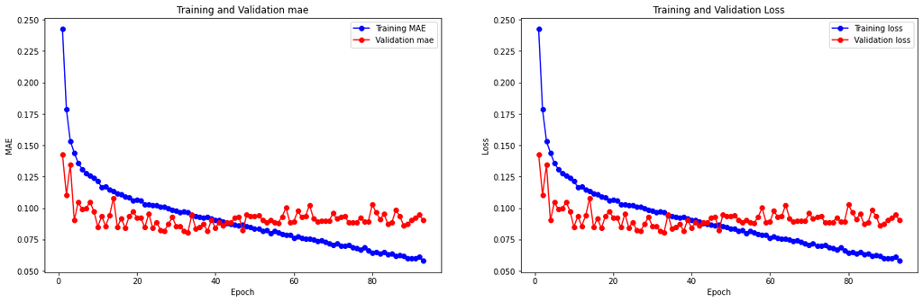

```
3132/3132 ━━━━━━━━━━━━━━━━━━━━ 1s 316us/step - loss: 0.0944 - mae: 0.0944
783/783 ━━━━━━━━━━━━━━━━━━━━ 1s 318us/step - loss: 0.0817 - mae: 0.0817
90/90 ━━━━━━━━━━━━━━━━━━━━ 0s 5ms/step - loss: 0.0949 - mae: 0.0949
```

```
Training MAE: 52299.50589192118
```

```
Validation MAE: 46227.052642048424
```

```python
plot(history)
train_MAE = model.evaluate(trainData)[-1] * stdSales
val_MAE = model.evaluate(valData)[-1] * stdSales
test_MAE = model.evaluate(testData)[-1] * stdSales
print(f"Training MAE: {train_MAE}")
print(f"Validation MAE: {val_MAE}")

save_model_results(val_results_path, model_name, val_MAE)
save_model_results(test_results_path, model_name, test_MAE)
```

# **Results summary and discussion**

## Obtaining the results

All the results have been saved previously for each model for both datasets. In this section, we collect all those results and create several dictionaries to use the utility function `plot_results_grouped`. This allows a clear comparison between the different models.

```python
val_results_path = os.path.join('.','val_results.csv')
test_results_path = os.path.join('.','test_results.csv')
```

```python
val_results = csv_to_dict(val_results_path)
test_results = csv_to_dict(test_results_path)
```

```python
test_results_by_model = filter_models_by_keywords(test_results, ['seq13','seq4', 'bidirectional', 'GRU', 'LSTM', 'SimpleRNN'])
val_results_by_model = filter_models_by_keywords(val_results, ['seq13','seq4', 'bidirectional', 'GRU', 'LSTM', 'SimpleRNN'])
```

## Results visualization and comparison

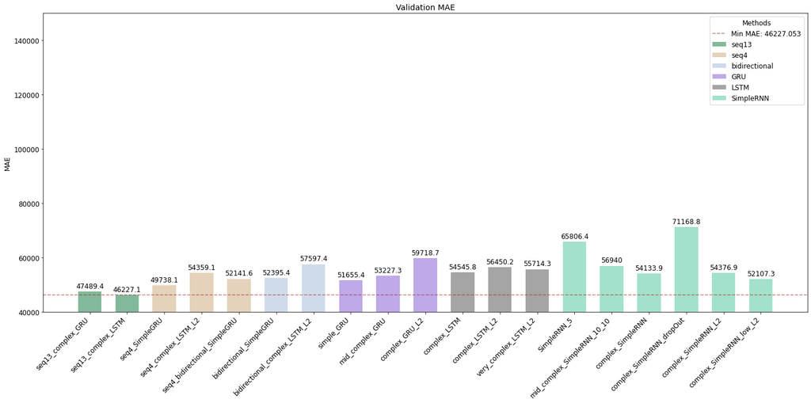

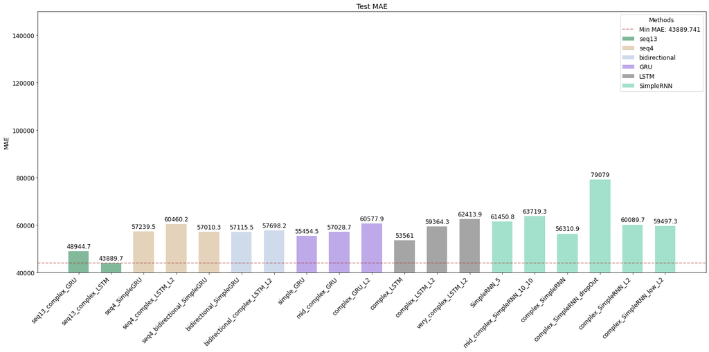

```python
plot_results_grouped(val_results_by_model, title='Validation MAE', y_lim=(40000, 150000))
plot_results_grouped(test_results_by_model, title='Test MAE', y_lim=(40000, 150000))
```

## Summary of Experimental Insights

Throughout our experimentation with various RNN architectures, including **SimpleRNNs**, **LSTMs** and **GRUs** methods, we've been trying to optimize the configuration of our models to achieve the best **MAE** possible in Walmart Sales prediction. Our experiments have spanned from basic models to increasingly complex iterations, incorporating techniques such as **dropout**, **L1**, **L2 regularization**, and configurations like **bidirectional layers**. In our exploration of **loss functions**, we tested several, including MSE, but found that **MAE** (Mean Absolute Error) yielded the best results, aligning closely with our chosen metric for performance evaluation. This could be attributed to its **alignment with our evaluation metric** and perhaps offering a more intuitive grasp of model performance.

One notable observation across the board was the models' pronounced **sensitivity to regularization**, which often led to a significant deterioration in performance when conventional approaches were applied, specially with strong regularization, such us high probabilities of dropout. Interestingly, the application of **very light L2 regularization** emerged as a slightly more effective strategy, enhancing training **stability** without severely compromising the learning capabilities.

A critical insight from our experiments is the delicate **balance** between model complexity and performance. Initially, augmenting the model's complexity seemed promising, as evidenced by improved metrics in medium-complexity RNNs. However, further increasing complexity, especially with **very complex** LSTM configurations, did not yield the anticipated benefits. This plateau suggests that there's an optimal level of complexity beyond which additional layers or neurons cease to contribute to performance improvement and may even degrade it.

Moreover, the exploration of bidirectional layers, particularly with GRU and LSTM models, provided mixed outcomes. While offering a nuanced understanding of sequential data by analyzing it from both directions, these configurations **didn't outperform their unidirectional counterparts**, underlining the importance of contextual appropriateness of architectural choices.

The experimentation also highlighted the **potential of extending sequence sizes**, which, in some cases, led to better model performance by providing a richer contextual backdrop for predictions. Consequently, the **LSTM model** using a **sequence of thirteen** is the one with **best test MAE** with a significant difference. This suggests that the amount of contextual information can be as crucial as the model architecture itself. It is also noteworthy that increasing the length of the sequences inherently leads to a **reduction** on the number of samples on the various datasets, which **may affect** the results.